# Coursework - Data Science I

Omar Zhadykov, 220220503

# Introduction

This coursework focuses on housing prices, with the main objective being to predict the price of a property based on various inputs. The inputs include features such as the area, the number and types of rooms, and additional factors like the availability of a main road, hot water heating, and more.

The dependent variable is the price, as it is the primary concern for most people searching for a house. The goal of this work is to predict the price based on diverse inputs, which consist of mixed data types, such as:

- Numerical values
- Text-based responses like “yes” or “no”
- Categories for furnishing status, including “furnished,” “semi-furnished,” or “non-furnished.”

This project addresses a regression problem because the objective is to predict a numeric value—in this case, the price of the property.

# Collection / Preparation

Now we are going to import our dataset into this project.

```r
dt_houses <- fread(file = "./Datasets/Regression_set.csv")
```

I would like to check, if i have some nullish data in my dataset. I think it is a good idea to go through all rows and colums and check, if there is a NA. I want to check it with built-in function in R *complete.cases(data_table)*. This function returns TRUE or FALSE if row contains a NA value.

```r
nas <- dt_houses[!complete.cases(dt_houses)]
nas
```

| price | area | bedrooms | bathrooms | stories | mainroad | guestroom | basement | hotwaterheating | airconditioning | parking | prefarea | furnishingstatus |
| --- | --- | --- | --- | --- | --- | --- | --- | --- | --- | --- | --- | --- |

That looks great, now we can explore our dataset :)

# Exploration

Explore your data by means of select summary statistics and visualizations and present interesting findings to your reader.

Before we will explore our data, I want to import all libraries, which we will probably use:

```r
library(data.table)
library(ggcorrplot)
library(ggExtra)
library(ggplot2)
library(ggridges)
library(ggsci)
library(ggthemes)
library(RColorBrewer)
library(svglite)
library(viridis)
library(scales)
library(rpart)
library(rpart.plot)
```

I found some helpful functions in R, so we could have a look on our data. We will start with a structure, than we will get some statistic data and take a *head()* of the data

```r
str(dt_houses)
```

```
Classes ‘data.table’ and 'data.frame':  545 obs. of  13 variables:
 $ price           : int  13300000 12250000 12250000 12215000 11410000 10850000 10150000 10150000 9870000 9800000 ...
 $ area            : int  7420 8960 9960 7500 7420 7500 8580 16200 8100 5750 ...
 $ bedrooms        : int  4 4 3 4 4 3 4 5 4 3 ...
 $ bathrooms       : int  2 4 2 2 1 3 3 3 1 2 ...
 $ stories         : int  3 4 2 2 2 1 4 2 2 4 ...
 $ mainroad        : chr  "yes" "yes" "yes" "yes" ...
 $ guestroom       : chr  "no" "no" "no" "no" ...
 $ basement        : chr  "no" "no" "yes" "yes" ...
 $ hotwaterheating : chr  "no" "no" "no" "no" ...
 $ airconditioning : chr  "yes" "yes" "no" "yes" ...
 $ parking         : int  2 3 2 3 2 2 2 0 2 1 ...
 $ prefarea        : chr  "yes" "no" "yes" "yes" ...
 $ furnishingstatus: chr  "furnished" "furnished" "semi-furnished" "furnished" ...
 - attr(*, ".internal.selfref")=<externalptr>
```

Statistic data:

```r
summary(dt_houses[, .(price, area, bedrooms, bathrooms, stories, parking)])
```

```
     price               area          bedrooms       bathrooms        stories         parking
 Min.   : 1750000   Min.   : 1650   Min.   :1.000   Min.   :1.000   Min.   :1.000   Min.   :0.0000
 1st Qu.: 3430000   1st Qu.: 3600   1st Qu.:2.000   1st Qu.:1.000   1st Qu.:1.000   1st Qu.:0.0000
 Median : 4340000   Median : 4600   Median :3.000   Median :1.000   Median :2.000   Median :0.0000
 Mean   : 4766729   Mean   : 5151   Mean   :2.965   Mean   :1.286   Mean   :1.806   Mean   :0.6936
 3rd Qu.: 5740000   3rd Qu.: 6360   3rd Qu.:3.000   3rd Qu.:2.000   3rd Qu.:2.000   3rd Qu.:1.0000
 Max.   :13300000   Max.   :16200   Max.   :6.000   Max.   :4.000   Max.   :4.000   Max.   :3.0000
```

and this is a sample of our dataset:

```r
head(dt_houses)
```

| price | area | bedrooms | bathrooms | stories | mainroad | guestroom | basement | hotwaterheating | airconditioning | parking | prefarea | furnishingstatus |
| --- | --- | --- | --- | --- | --- | --- | --- | --- | --- | --- | --- | --- |
| 13300000 | 7420 | 4 | 2 | 3 | yes | no | no | no | yes | 2 | yes | furnished |
| 12250000 | 8960 | 4 | 4 | 4 | yes | no | no | no | yes | 3 | no | furnished |
| 12250000 | 9960 | 3 | 2 | 2 | yes | no | yes | no | no | 2 | yes | semi-furnished |
| 12215000 | 7500 | 4 | 2 | 2 | yes | no | yes | no | yes | 3 | yes | furnished |
| 11410000 | 7420 | 4 | 1 | 2 | yes | yes | yes | no | yes | 2 | no | furnished |
| 10850000 | 7500 | 3 | 3 | 1 | yes | no | yes | no | yes | 2 | yes | semi-furnished |

I would like to start from density of a main values, which are from my domain knowledge are important in price of the properties

We will start with price density:

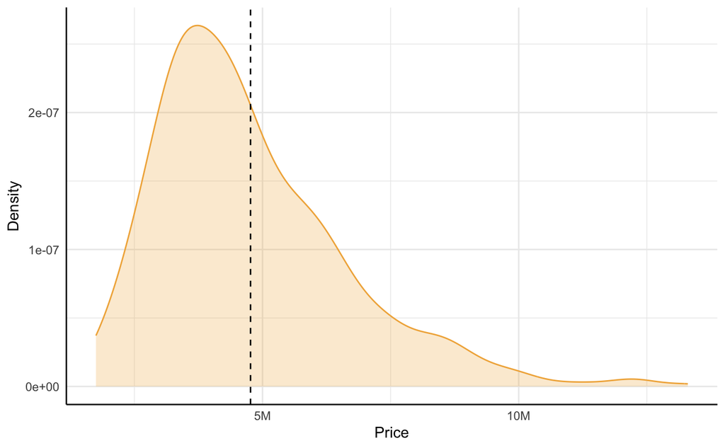

```r
ggplot(data = dt_houses, aes(x = price)) +
  geom_density(fill="#f1b147", color="#f1b147", alpha=0.25) +
  labs(
    x = 'Price',
    y = 'Density'
  ) +
  geom_vline(xintercept = mean(dt_houses$price), linetype="dashed") +
  scale_x_continuous(labels = label_number(scale = 1e-6, suffix = "M")) +
  theme_minimal() +
  theme(axis.line = element_line(color = "#000000"))
```

Also it would be greate to have a look at area density:

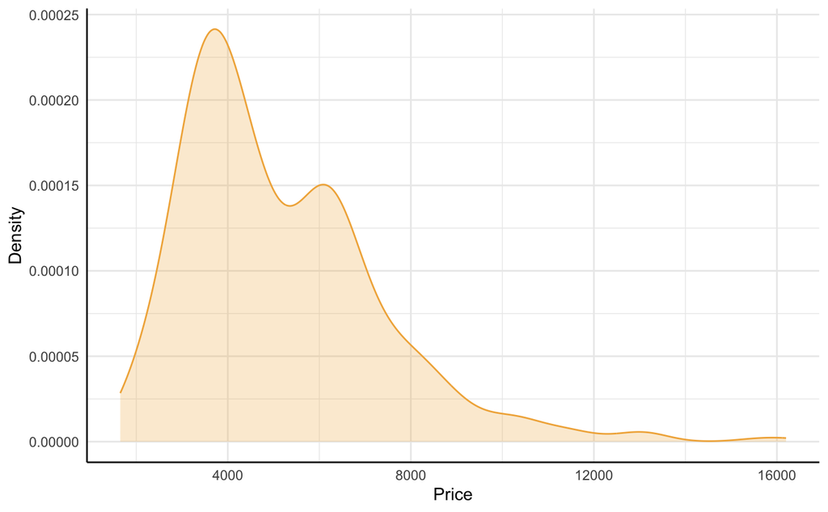

```r
ggplot(data = dt_houses, aes(x = area)) +
  geom_density(fill="#f1b147", color="#f1b147", alpha=0.25) +
  labs(
    x = 'Price',
    y = 'Density'
  ) +
  theme_minimal() +
  theme(axis.line = element_line(color = "#000000"))
```

This is interesting, how does area affect price of the house. We will plot it with points, where price is on the y-axis and area on x-axis.

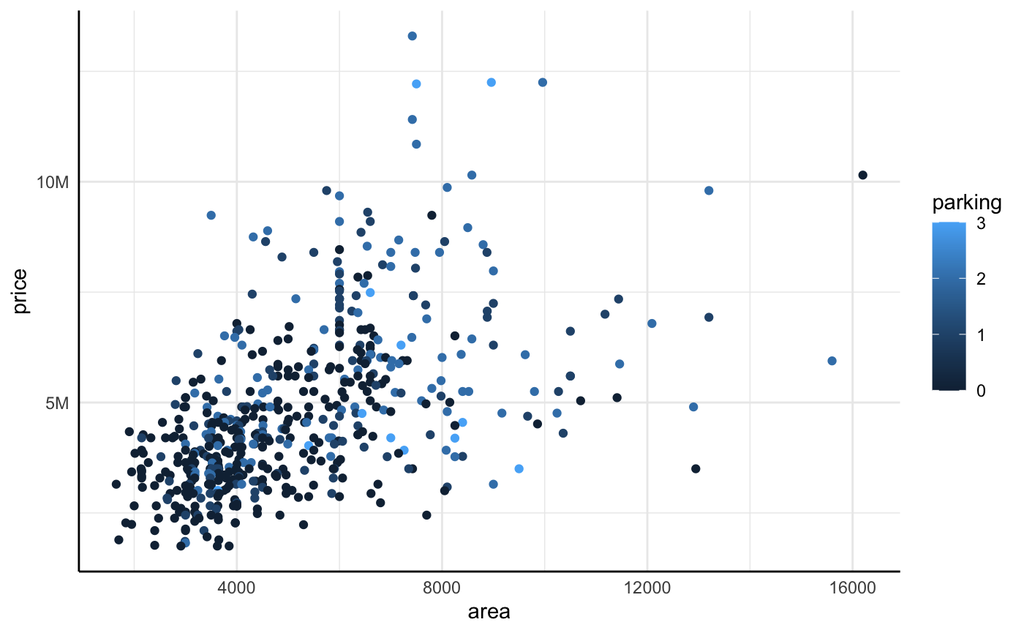

```r
ggplot() +
  geom_point(data = dt_houses, aes(x = area, y = price, color = parking)) +
  scale_y_continuous(labels = label_number(scale = 1e-6, suffix = "M")) +
  theme_minimal() +
  theme(axis.line = element_line(color = "#000000"))
```

This looks nice, and it is also logical, more space, higher price.

But, now I have the simplest idea, how does amount of bedrooms correlates with the price.

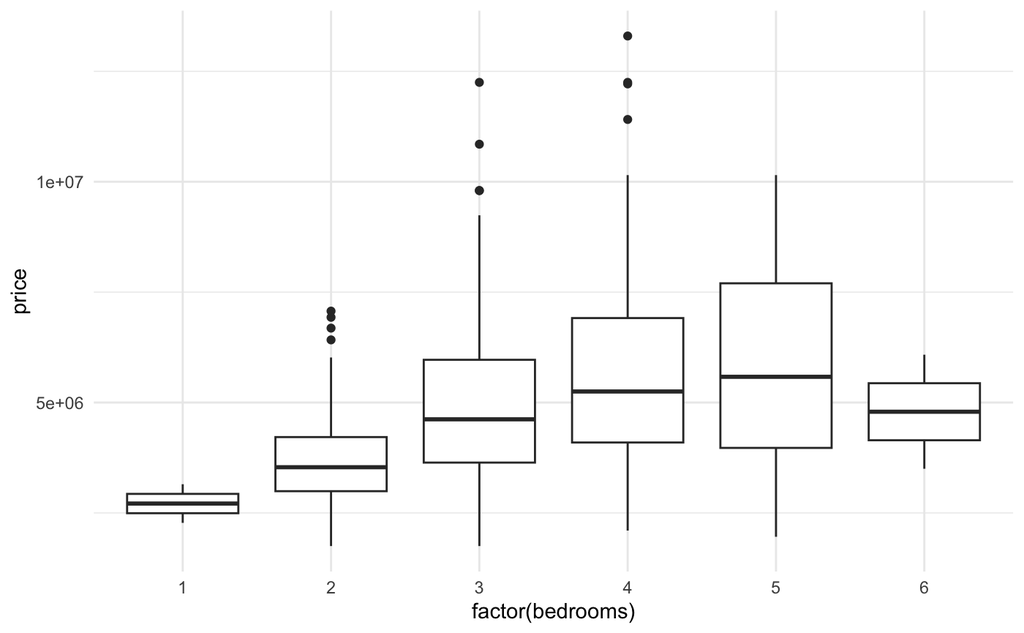

```r
ggplot(data = dt_houses, aes(x = factor(bedrooms), y = price)) +
  geom_boxplot() +
  theme_minimal()
```

We can see, that on average, more bedrooms, means higher price, but I think there is not really strong relationship between this two variables.

Also it would be great to take a look at a bedrooms histogram:

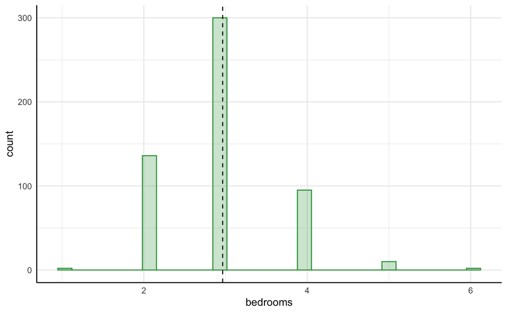

```r
ggplot(data = dt_houses, aes(x = bedrooms)) +
  geom_histogram(fill="#2f9e44", color="#2f9e44", alpha=0.25) +
  geom_vline(xintercept = mean(dt_houses$bedrooms), linetype="dashed") +
  theme_minimal() +
  theme(axis.line = element_line(color = "#000000"))
```

Also I want to show you the mean of the bedrooms:

```r
mean(dt_houses$bedrooms)
```

```
[1] 2.965138
```

Here we can see, that the most of the properties tend to have 2, 3 or 4 rooms.

Let’s also have a look at density and mean value of a stories:

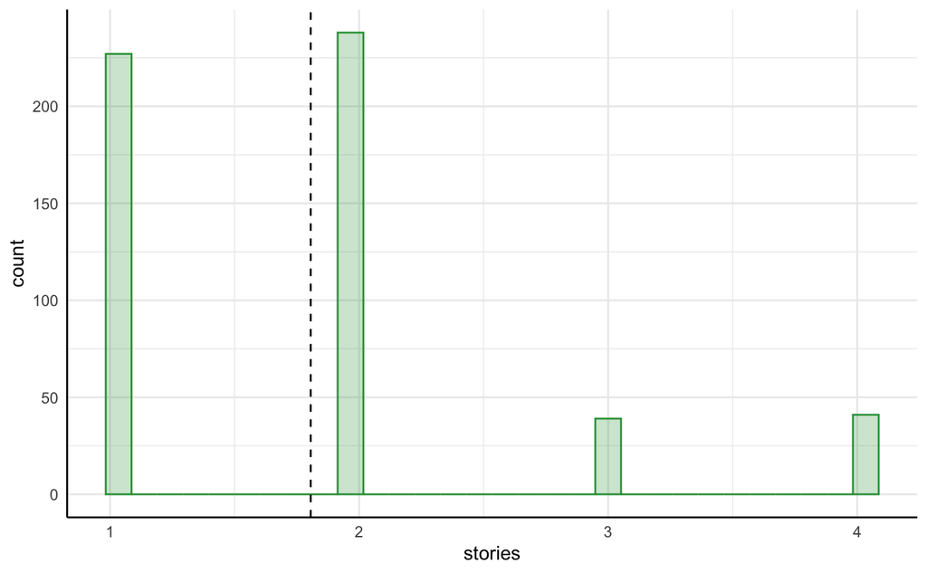

```r
ggplot(data = dt_houses, aes(x = stories)) +
  geom_histogram(fill="#2f9e44", color="#2f9e44", alpha=0.25) +
  geom_vline(xintercept = mean(dt_houses$stories), linetype="dashed") +
  theme_minimal() +
  theme(axis.line = element_line(color = "#000000"))
```

```r
mean(dt_houses$stories)
```

```
[1] 1.805505
```

It is interesting how much real estate furnished or not

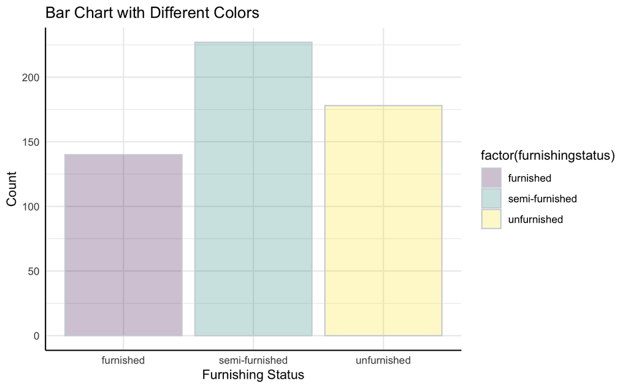

```r
ggplot(data = dt_houses, aes(x = factor(furnishingstatus), fill = factor(furnishingstatus))) +
  geom_bar(color="#ced4da", alpha=0.25) +
  scale_fill_viridis_d(option = "D") +
  labs(title = "Bar Chart with Different Colors",
       x = "Furnishing Status",
       y = "Count") +
  theme_minimal() +
  theme(axis.line = element_line(color = "#000000"))
```

Now, it would be great, to look at price and area distribution in differently furnished properties

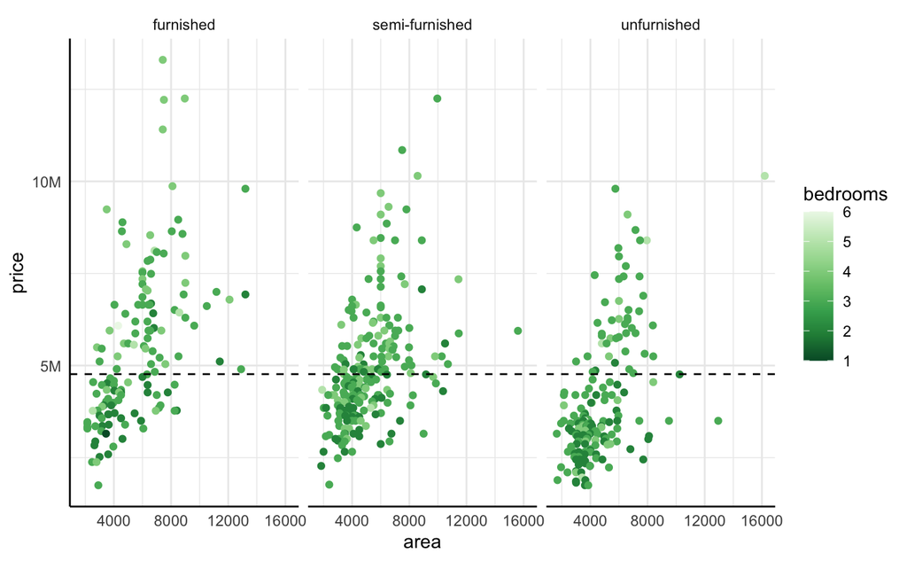

```r
ggplot(data = dt_houses, aes(y = price, x = area)) +
  geom_point(data = dt_houses, aes(y = price, x = area, color = bedrooms)) +
  geom_hline(yintercept = mean(dt_houses$price), linetype='dashed') +
  facet_grid(.~furnishingstatus) +
  scale_y_continuous(labels = label_number(scale = 1e-6, suffix = "M")) +
  scale_color_distiller(type = "seq", palette = "Greens") +
  theme_minimal() +
  theme(axis.line = element_line(color = "#000000"))
```

We can also take a look on some pie charts:

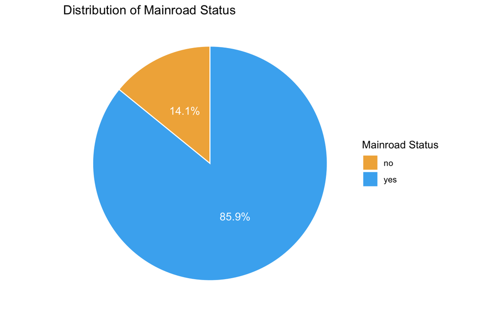

```r
dt_mainroad_counts <- as.data.frame(table(dt_houses$mainroad)) #table() - creates frequency table
colnames(dt_mainroad_counts) <- c("mainroad_status", "count")
dt_mainroad_counts$percentage <- round(dt_mainroad_counts$count / sum(dt_mainroad_counts$count) * 100, 1)

ggplot(data = dt_mainroad_counts, aes(x = "", y = count, fill = mainroad_status)) +
  geom_bar(stat = "identity", width = 1, color = "white") +
  coord_polar("y", start = 0) +
  geom_text(aes(label = paste0(percentage, "%")),
            position = position_stack(vjust = 0.5), color = "white", size = 4) +
  theme_void() +
  scale_fill_manual(values = c("#F1B147", "#47B1F1")) +
  labs(
    title = "Distribution of Mainroad Status",
    fill = "Mainroad Status"
  )
```

I think that would be enough exlporation and we can start with our first model.